# Clicker Questions for DS2 - Foundations of Data Science

to go along with

**[Modern Data Science with R, 3rd edition](https://mdsr-book.github.io/mdsr3e/)** by Baumer, Kaplan, and Horton

**[R for Data Science, 2nd edition](https://r4ds.hadley.nz/)** by Wickham, Çetinkaya-Rundel, and Grolemund

1. R / Positron / Quarto[^1]
   1. all good
   2. started, progress is slow and steady
   3. started, very stuck
   4. haven’t started yet
   5. what do you mean by “R”?
2. Git / GitHub[^2]
   1. all good
   2. started, progress is slow and steady
   3. started, very stuck
   4. haven’t started yet
   5. what do you mean by “Git”?
3. Where can I get feedback on my HW assignments / quizzes?[^3]
   1. prof will return paper versions
   2. on Gradescope
   3. on Canvas
   4. on GitHub
4. Which of the following includes talking to the remote version of GitHub?[^4]
   1. changing your name (updating the YAML)
   2. committing the file(s)
   3. pushing the file(s)
   4. some of the above
   5. all of the above
5. What is the error?[^5]
   1. poor assignment operator
   2. unmatched quotes
   3. improper syntax for function argument
   4. invalid object name
   5. no mistake

```r
shup2 <- -"Hello to you!"
```

6. What is the error?[^6]
   1. poor assignment operator
   2. unmatched quotes
   3. improper syntax for function argument
   4. invalid object name
   5. no mistake

```r
3shup <- "Hello to you!"
```

7. What is the error?[^7]
   1. poor assignment operator
   2. unmatched quotes
   3. improper syntax for function argument
   4. invalid object name
   5. no mistake

```r
shup4 <-  "Hello to you!
```

8. What is the error?[^8]
   1. poor assignment operator
   2. unmatched quotes
   3. improper syntax for function argument
   4. invalid object name
   5. no mistake

```r
shup5 <- date()
```

9. What is the error?[^9]
   1. poor assignment operator
   2. unmatched quotes
   3. improper syntax for function argument
   4. invalid object name
   5. no mistake

```r
shup6 <- sqrt 10
```

10. Do you keep a calendar / schedule / planner?[^10]
    1. Yes
    2. No
11. Do you keep a calendar / schedule / planner? If you answered “Yes” …[^11]
    1. Yes, on Google Calendar
    2. Yes, on Calendar for macOS
    3. Yes, on Outlook for Windows
    4. Yes, in some other app
    5. Yes, by hand
12. Where should I put things I’ve created for the HW (e.g., data, .ics file, etc.)[^12]
    1. Upload into remote GitHub directory
    2. In the local folder which also has the R project
    3. In my Downloads
    4. Somewhere on my Desktop
    5. In my Home directory
13. The goal of making a figure is…[^13]
    1. To draw attention to your work.
    2. To facilitate comparisons.
    3. To provide as much information as possible.
14. A good reason to make a particular choice of a graph is:[^14]
    1. Because the journal / field has particular expectations for how the data are presented.
    2. Because some variables naturally fit better on some graphs (e.g., numbers on scatter plots).
    3. Because that graphic displays the message you want as optimally as possible.
15. What are the visual cues on this plot?[^15]
1. position
2. length
3. shape
4. area/volume
5. shade/color

[figure not shown]

16. What are the visual cues on this plot?[^16]
1. position
2. length
3. shape
4. area/volume
5. shade/color

[figure not shown]

17. What are the visual cues on this plot?[^17]
1. position
2. length
3. shape
4. area/volume
5. shade/color

[figure not shown]

18. Why are the points orange?[^18]
    1. R translates “navy” into orange.
    2. color must be specified in `geom_point()`
    3. color must be specified **outside** the `aes()` function
    4. the default plot color is orange

[figure not shown]

```r
ggplot(
  data = Births2015,
  aes(x = date, y = births, color = "navy")
) +
  geom_point() +
  labs(title = "US Births in 2015")
```

19. Why are the dots blue and the lines colored?[^19]
    1. dot color is given as “navy”, line color is given as `wday`.
    2. both colors are specified in the `ggplot()` function.
    3. dot coloring takes precedence over line coloring.
    4. line coloring takes precedence over dot coloring.

[figure not shown]

20. Setting vs. Mapping. If I want information to be passed to all data points (not variable):[^20]
    1. map the information inside the `aes()` function.
    2. set the information outside the `aes()` function
21. The Snow figure was most successful at:[^21]
    1. making the data stand out
    2. facilitating comparison
    3. putting the work in context
    4. simplifying the story
22. The Challenger figure(s) was(were) least successful at:[^22]
    1. making the data stand out
    2. facilitating comparison
    3. putting the work in context
    4. simplifying the story
23. The biggest difference between Snow and the Challenger was:[^23]
    1. The **amount** of information portrayed.
    2. One was better at displaying **cause**.
    3. One showed the relevant **comparison** better.
    4. One was more **artistic**.
24. Caffeine and Calories. What was the biggest concern over the average value axes?[^24]
    1. It isn’t at the origin.
    2. They should have used all the data possible to find averages.
    3. There wasn’t a random sample.
    4. There wasn’t a label explaining why the axes were where they were.
25. Why is there no `y` designation in the `aes()` function for the `geom_bar()` geometry?[^25]
    1. It is outside the `aes()` function.
    2. There is a default value for what `y` should be when not specified.
    3. `y` is specified in `ggplot()`.
    4. The job of a bar plot is to count the number of instances.
    5. The `y` variable is the same as the `x` variable.
26. What is the difference between `fill = children` and `position = "fill"`?[^26]
    1. `fill = children` colors and `position = "fill"` changes the y-axis
    2. `fill = children` changes the y-axis and `position = "fill"` colors
    3. `fill = children` goes in the aes and `position = "fill"` goes outside the aes
    4. `fill = children` goes outside the aes and `position = "fill"` goes inside the aes
    5. `fill = children` and `position = "fill"` are two different ways to write the same thing.
27. What is the difference between `geom_bar()` and `geom_histogram()`?[^27]
    1. They are the different names for the same function.
    2. `geom_bar()` is for numbers and `geom_histogram()` is for categorical variables.
    3. `geom_bar()` is for categorical variables and `geom_histogram()` is for numbers.
    4. `geom_bar()` produces counts and `geom_histogram()` produces percentages.
    5. `geom_bar()` produces percentages and `geom_histogram()` produces counts.
28. Which data represents the ideal format for **ggplot2** and **dplyr**?[^28]

table a

| year | Algeria | Brazil | Columbia |
| --- | --- | --- | --- |
| 2000 | 7 | 12 | 16 |
| 2001 | 9 | 14 | 18 |

table b

| country | Y2000 | Y2001 |
| --- | --- | --- |
| Algeria | 7 | 9 |
| Brazil | 12 | 14 |
| Columbia | 16 | 18 |

table c

| country | year | value |
| --- | --- | --- |
| Algeria | 2000 | 7 |
| Algeria | 2001 | 9 |
| Brazil | 2000 | 12 |
| Brazil | 2001 | 14 |
| Columbia | 2000 | 16 |
| Columbia | 2001 | 18 |

29. What is wrong with the following code?[^29]
    1. should only be one =
    2. `Bakery` should be upper case
    3. `type` should not be in quotes
    4. use mutate instead of filter
    5. `starbucks` in wrong place

```r
Result <- |> filter(starbucks,
        type == "bakery")
```

30. Each of the statements except one will accomplish the same calculation. Which one does not match?[^30]

```r
#(a)
starbucks |>
  group_by(type) |>
  summarize(average_fat = mean(fat))

#(b)
group_by(starbucks, type) |>
  summarize(average_fat = mean(fat))

#(c)
group_by(starbucks, type) |>
  summarize(average_fat = sum(fat))

#(d)
temp <- group_by(starbucks, type)

summarize(temp, average_fat = mean(fat))

#(e)
summarize(group_by(starbucks, type), average_fat = mean(fat))
```

31. Fill in Q1.[^31]
    1. `filter()`
    2. `arrange()`
    3. `select()`
    4. `mutate()`
    5. `group_by()`

```r
result <- lego_sample |>
  Q1(!is.na(minifigures)) |>
  # keep only those with minifigures
  group_by(Q2, Q2) |>
  summarize(total = Q3)
```

32. Fill in Q2.[^32]
    1. `(theme, price)`
    2. `(theme, year)`
    3. `(year, price)`
    4. `(pieces, year)`
    5. `(pieces, price)`

```r
result <- lego_sample |>
  Q1(!is.na(minifigures)) |>
  group_by(Q2, Q2) |>
  # for each theme and year
  summarize(total = Q3)
```

33. Fill in Q3.[^33]
    1. `n_distinct(pieces)`
    2. `n_distinct(price)`
    3. `sum(pieces)`
    4. `sum(pages)`
    5. `mean(pieces)`

```r
result <- lego_sample |>
  Q1(!is.na(minifigures)) |>
  group_by(Q2, Q2) |>
  summarize(ave_pieces = Q3)
# average number of pieces (each theme, each year)
```

34. Running the code.[^34]

```r
library(openintro)
lego_sample |>
  filter(!is.na(minifigures)) |>
  # keep only those with minifigures
  group_by(theme, year) |>
  # for each theme for each year
  summarize(ave_pieces = mean(pieces))
```

```
# A tibble: 9 × 3
# Groups:   theme [3]
  theme    year ave_pieces
  <chr>   <dbl>      <dbl>
1 City     2018      189.
2 City     2019      257.
3 City     2020      349
4 DUPLO®   2018       50.5
5 DUPLO®   2019       32.5
6 DUPLO®   2020       45.8
7 Friends  2018      354.
8 Friends  2019      259.
9 Friends  2020      250.
```

```r
#(a)
starbucks |>
  group_by(type) |>
  summarize(average_fat = mean(fat))
```

```
# A tibble: 7 × 2
  type          average_fat
  <fct>               <dbl>
1 bakery              14.6
2 bistro box          18.4
3 hot breakfast       13.7
4 parfait              6.5
5 petite               9.33
6 salad                0
7 sandwich            14.7
```

```r
#(b)
group_by(starbucks, type) |>
  summarize(average_fat = mean(fat))
```

```
# A tibble: 7 × 2
  type          average_fat
  <fct>               <dbl>
1 bakery              14.6
2 bistro box          18.4
3 hot breakfast       13.7
4 parfait              6.5
5 petite               9.33
6 salad                0
7 sandwich            14.7
```

```r
#(c)
group_by(starbucks, type) |>
  summarize(average_fat = sum(fat))
```

```
# A tibble: 7 × 2
  type          average_fat
  <fct>               <dbl>
1 bakery              597
2 bistro box          147
3 hot breakfast       110.
4 parfait              19.5
5 petite               84
6 salad                 0
7 sandwich            103
```

```r
#(d)
temp <- group_by(starbucks, type)

summarize(temp, average_fat = mean(fat))
```

```
# A tibble: 7 × 2
  type          average_fat
  <fct>               <dbl>
1 bakery              14.6
2 bistro box          18.4
3 hot breakfast       13.7
4 parfait              6.5
5 petite               9.33
6 salad                0
7 sandwich            14.7
```

```r
#(e)
summarize(group_by(starbucks, type), average_fat = mean(fat))
```

```
# A tibble: 7 × 2
  type          average_fat
  <fct>               <dbl>
1 bakery              14.6
2 bistro box          18.4
3 hot breakfast       13.7
4 parfait              6.5
5 petite               9.33
6 salad                0
7 sandwich            14.7
```

35. Where can I get feedback on my HW assignments / quizzes?[^35]
    1. prof will return paper versions
    2. on Gradescope
    3. on Canvas
    4. on GitHub
36. Where can I get feedback on my projects?[^36]
    1. prof will return paper versions
    2. on Gradescope
    3. on Canvas
    4. on GitHub
37. Fill in Q1.[^37]
    1. `gdp`
    2. `year`
    3. `gdpval`
    4. `country`
    5. `–country`

```r
GDP |>
  select(country = starts_with("Income"), everything()) |>
  pivot_longer(cols = Q1, names_to = Q2, values_to = Q3)
```

38. Fill in Q2.[^38]
    1. `gdp`
    2. `year`
    3. `gdpval`
    4. `country`
    5. `–country`

```r
GDP |>
  select(country = starts_with("Income"), everything()) |>
  pivot_longer(cols = Q1, names_to = Q2, values_to = Q3)
```

39. Fill in Q3.[^39]
    1. `gdp`
    2. `year`
    3. `gdpval`
    4. `country`
    5. `–country`

```r
GDP |>
  select(country = starts_with("Income"), everything()) |>
  pivot_longer(cols = Q1, names_to = Q2, values_to = Q3)
```

40. You’d like to use the data to make a plot with `Midterm` score on the x-axis and `Final` score on the y-axis using the following `ggplot()` code. Which data frame should you use?[^40]
    1. use raw data
    2. use `pivot_wider()` on raw data
    3. use `pivot_longer()` on raw data

```r
ggplot(___, aes(x = ___, y = ___, color = ___)) +
  geom_point()
```

```
# A tibble: 4 × 3
  student test    score
  <chr>   <chr>   <dbl>
1 Alice   Midterm    85
2 Alice   Final      90
3 Bob     Midterm    78
4 Bob     Final      82
```

```r
grades |>
  pivot_wider(names_from = test, values_from = score)
```

```
# A tibble: 2 × 3
  student Midterm Final
  <chr>     <dbl> <dbl>
1 Alice        85    90
2 Bob          78    82
```

```r
grades |>
  pivot_wider(names_from = test, values_from = score) |>
  ggplot(aes(x = Midterm, y = Final, color = student)) +
  geom_point()
```

[figure not shown]

41. Response to stimulus (in ms) after only 3 hrs of sleep for 9 days. You want to make a plot with the subject’s reaction time (y-axis) vs the number of days of sleep restriction (x-axis) using the following `ggplot()` code. Which data frame should you use?[^41]
    1. use raw data
    2. use `pivot_wider()` on raw data
    3. use `pivot_longer()` on raw data

```r
ggplot(___, aes(x = ___, y = ___, color = ___)) +
  geom_line()
```

```
# A tibble: 18 × 11
   Subject day_0 day_1 day_2 day_3 day_4 day_5 day_6 day_7 day_8 day_9
     <dbl> <dbl> <dbl> <dbl> <dbl> <dbl> <dbl> <dbl> <dbl> <dbl> <dbl>
 1     308  250.  259.  251.  321.  357.  415.  382.  290.  431.  466.
 2     309  223.  205.  203.  205.  208.  216.  214.  218.  224.  237.
 3     310  199.  194.  234.  233.  229.  220.  235.  256.  261.  248.
 4     330  322.  300.  284.  285.  286.  298.  280.  318.  305.  354.
 5     331  288.  285   302.  320.  316.  293.  290.  335.  294.  372.
 6     332  235.  243.  273.  310.  317.  310   454.  347.  330.  254.
 7     333  284.  290.  277.  300.  297.  338.  332.  349.  333.  362.
 8     334  265.  276.  243.  255.  279.  284.  306.  332.  336.  377.
 9     335  242.  274.  254.  271.  251.  255.  245.  235.  236.  237.
10     337  312.  314.  292.  346.  366.  392.  404.  417.  456.  459.
11     349  236.  230.  239.  255.  251.  270.  282.  308.  336.  352.
12     350  256.  243.  256.  256.  269.  330.  379.  363.  394.  389.
13     351  251.  300.  270.  281.  272.  305.  288.  267.  322.  348.
14     352  222.  298.  327.  347.  349.  353.  354.  360.  376.  389.
15     369  272.  268.  257.  278.  315.  317.  298.  348.  340.  367.
16     370  225.  235.  239.  240.  268.  344.  281.  348.  365.  372.
17     371  270.  272.  278.  282.  279.  285.  259.  305.  351.  369.
18     372  269.  273.  298.  311.  287.  330.  334.  343.  369.  364.
```

```r
sleep_long <- sleep_wide |>
  pivot_longer(
    cols = -Subject,
    names_to = "day",
    names_prefix = "day_",
    values_to = "reaction_time"
  )

sleep_long
```

```
# A tibble: 180 × 3
   Subject day   reaction_time
     <dbl> <chr>         <dbl>
 1     308 0              250.
 2     308 1              259.
 3     308 2              251.
 4     308 3              321.
 5     308 4              357.
 6     308 5              415.
 7     308 6              382.
 8     308 7              290.
 9     308 8              431.
10     308 9              466.
# ℹ 170 more rows
```

```r
sleep_wide |>
  pivot_longer(
    cols = -Subject,
    names_to = "day",
    names_prefix = "day_",
    values_to = "reaction_time"
  ) |>
  ggplot(aes(
    x = day,
    y = reaction_time,
    color = as.factor(Subject),
    group = as.factor(Subject)
  )) +
  geom_line()
```

[figure not shown]

42. Consider band members from the Beatles and the Rolling Stones. Who is removed in a `right_join()`?[^42]
1. Mick
2. John
3. Paul
4. Keith
5. Impossible to know

```r
band_members
```

```
# A tibble: 3 × 2
  name  band
  <chr> <chr>
1 Mick  Stones
2 John  Beatles
3 Paul  Beatles
```

```r
band_instruments
```

```
# A tibble: 3 × 2
  name  plays
  <chr> <chr>
1 John  guitar
2 Paul  bass
3 Keith guitar
```

```r
band_members |>
  right_join(band_instruments, by = "name")
```

43. Consider band members from the Beatles and the Rolling Stones. Which variables are removed in a `right_join()`?[^43]
1. `name`
2. `band`
3. `plays`
4. none of them

```r
band_members
```

```
# A tibble: 3 × 2
  name  band
  <chr> <chr>
1 Mick  Stones
2 John  Beatles
3 Paul  Beatles
```

```r
band_instruments
```

```
# A tibble: 3 × 2
  name  plays
  <chr> <chr>
1 John  guitar
2 Paul  bass
3 Keith guitar
```

```r
band_members |>
  right_join(band_instruments, by = "name")
```

44. What happens to Mick’s `plays` variable in a `full_join()`?[^44]
1. Mick is removed
2. changes to guitar
3. changes to bass
4. `NA`
5. `NULL`

```r
band_members
```

```
# A tibble: 3 × 2
  name  band
  <chr> <chr>
1 Mick  Stones
2 John  Beatles
3 Paul  Beatles
```

```r
band_instruments
```

```
# A tibble: 3 × 2
  name  plays
  <chr> <chr>
1 John  guitar
2 Paul  bass
3 Keith guitar
```

```r
band_members |>
  full_join(band_instruments, by = "name")
```

45. Students on the roster but not in any class.[^45]
    1. `roster |> inner_join(classes, by = "student_id") |> filter(major != subject)`
    2. `classes |> anti_join(roster, by = "student_id")`
    3. `roster |> anti_join(classes, by = "student_id")`
    4. `roster |> full_join(classes, by = "student_id")`
    5. `roster |> semi_join(classes, by = "student_id")`

```r
roster
```

```
# A tibble: 5 × 3
  student_id name  major
       <dbl> <chr> <chr>
1          1 Alice Math
2          2 Ben   CS
3          3 Carla History
4          4 David CS
5          5 Eva   Math
```

```r
classes
```

```
# A tibble: 5 × 3
  student_id class       subject
       <dbl> <chr>       <chr>
1          1 Calc I      Math
2          2 Intro CS    CS
3          2 Data Struct CS
4          4 Intro CS    CS
5          6 Chemistry   Chemistry
```

46. All students on the roster and all enrollments.[^46]
    1. `roster |> inner_join(classes, by = "student_id") |> filter(major != subject)`
    2. `classes |> anti_join(roster, by = "student_id")`
    3. `roster |> anti_join(classes, by = "student_id")`
    4. `roster |> full_join(classes, by = "student_id")`
    5. `roster |> semi_join(classes, by = "student_id")`

```r
roster
```

```
# A tibble: 5 × 3
  student_id name  major
       <dbl> <chr> <chr>
1          1 Alice Math
2          2 Ben   CS
3          3 Carla History
4          4 David CS
5          5 Eva   Math
```

```r
classes
```

```
# A tibble: 5 × 3
  student_id class       subject
       <dbl> <chr>       <chr>
1          1 Calc I      Math
2          2 Intro CS    CS
3          2 Data Struct CS
4          4 Intro CS    CS
5          6 Chemistry   Chemistry
```

47. Students from the roster who are enrolled in at least one class.[^47]
    1. `roster |> inner_join(classes, by = "student_id") |> filter(major != subject)`
    2. `classes |> anti_join(roster, by = "student_id")`
    3. `roster |> anti_join(classes, by = "student_id")`
    4. `roster |> full_join(classes, by = "student_id")`
    5. `roster |> semi_join(classes, by = "student_id")`

```r
roster
```

```
# A tibble: 5 × 3
  student_id name  major
       <dbl> <chr> <chr>
1          1 Alice Math
2          2 Ben   CS
3          3 Carla History
4          4 David CS
5          5 Eva   Math
```

```r
classes
```

```
# A tibble: 5 × 3
  student_id class       subject
       <dbl> <chr>       <chr>
1          1 Calc I      Math
2          2 Intro CS    CS
3          2 Data Struct CS
4          4 Intro CS    CS
5          6 Chemistry   Chemistry
```

48. Students in a class but not on the roster.[^48]
    1. `roster |> inner_join(classes, by = "student_id") |> filter(major != subject)`
    2. `classes |> anti_join(roster, by = "student_id")`
    3. `roster |> anti_join(classes, by = "student_id")`
    4. `roster |> full_join(classes, by = "student_id")`
    5. `roster |> semi_join(classes, by = "student_id")`

```r
roster
```

```
# A tibble: 5 × 3
  student_id name  major
       <dbl> <chr> <chr>
1          1 Alice Math
2          2 Ben   CS
3          3 Carla History
4          4 David CS
5          5 Eva   Math
```

```r
classes
```

```
# A tibble: 5 × 3
  student_id class       subject
       <dbl> <chr>       <chr>
1          1 Calc I      Math
2          2 Intro CS    CS
3          2 Data Struct CS
4          4 Intro CS    CS
5          6 Chemistry   Chemistry
```

49. Students on the roster taking at least one class outside their major.[^49]
    1. `roster |> inner_join(classes, by = "student_id") |> filter(major != subject)`
    2. `classes |> anti_join(roster, by = "student_id")`
    3. `roster |> anti_join(classes, by = "student_id")`
    4. `roster |> full_join(classes, by = "student_id")`
    5. `roster |> semi_join(classes, by = "student_id")`

```r
roster
```

```
# A tibble: 5 × 3
  student_id name  major
       <dbl> <chr> <chr>
1          1 Alice Math
2          2 Ben   CS
3          3 Carla History
4          4 David CS
5          5 Eva   Math
```

```r
classes
```

```
# A tibble: 5 × 3
  student_id class       subject
       <dbl> <chr>       <chr>
1          1 Calc I      Math
2          2 Intro CS    CS
3          2 Data Struct CS
4          4 Intro CS    CS
5          6 Chemistry   Chemistry
```

50. What is the output of the following R code?[^50]
1. “a 1” “b 2” “c 3”
2. “a, 1” “b, 2” “c, 3”
3. “a1” “b2” “c3”
4. “a b c” “1 2 3”
5. “abc” “123”

```r
str_c(letters = c("a", "b", "c"), numbers = c(1, 2, 3))
```

51. What is the output of the following R code?[^51]
1. “a 1” “b 2” “c 3”
2. “a, 1” “b, 2” “c, 3”
3. “a1” “b2” “c3”
4. “a b c” “1 2 3”
5. “abc” “123”

```r
str_c(letters = c("a", "b", "c"), numbers = c(1, 2, 3), sep = " ")
```

52. What is the output of the following R code?[^52]
    1. “abc” “hifg”
    2. “ab” “hifg”
    3. “ab” “ifg”
    4. “abc” “ifg”

```r
x <- c("abcde", "ghifgh")
str_sub(x, start = c(1, 3), end = c(2, 5))
```

53. What is the output of the following R code?[^53]
1. “one -pple” “two p-ars” “three bananas”
2. “on- -ppl-” “two p–rs” “thr– b-n-n-s”
3. “on- apple” “two p-ars” “thr-e bananas”

```r
fruits <- c("one apple", "two pears", "three bananas")
str_replace(fruits, pattern = c("a", "e", "i"), replacement = "-")
```

54. What is the output of the following R code?[^54]
1. TRUE
2. TRUE TRUE TRUE TRUE
3. TRUE FALSE FALSE FALSE
4. FALSE

```r
fruit <- c("apple", "banana", "pear", "pineapple")
str_detect(fruit, pattern = "a")
```

55. If unspecified, the levels of a factor variable will be ordered:[^55]
    1. in the order that they first show up in the dataset
    2. from shortest to longest in terms of characters
    3. from longest to shortest in terms of characters
    4. alphabetically, from a to z
    5. alphabetically, from z to a
56. What does this code do?[^56]
    1. New variable which is the average of the `calories`
    2. New variable which is the average of the `type`
    3. Changes the values of `type`
    4. Changes the levels of `type`
    5. Changes the order of the levels of `type`

```r
starbucks |>
  mutate(type = fct_reorder(type, calories, .fun = "mean", .desc = TRUE))
```

57. What does `fct_recode()` do here?[^57]
    1. Creates a new variable
    2. Changes the values of `x`
    3. Changes the levels of `x`
    4. Changes the order of the levels of `x`
    5. Some of the above
    6. All of the above

```r
x <- factor(c("apple", "bear", "dear", "banana"))
x
fct_recode(x, fruit = "apple", fruit = "banana")
```

58. What is January 31 + one month?[^58]
    1. February 31
    2. March 3
    3. February 28 (assuming no leap year)
    4. I don’t want to answer the question
59. What is the difference between code lines 3 and 4 below?[^59]
    1. same thing
    2. different months
    3. different output formatting
    4. different input
    5. different calculation

```r
library(lubridate)
today <- now()
month(today)
month(today, label = TRUE)
```

60. What does this number mean?[^60]
    1. Today is the 42th day of the month.
    2. Today is the 42th day of the year.
    3. Today is the 42th week of the month.
    4. Today is the 42th week of the year.

```r
today <- now()
week(today)
```

```
[1] 42
```

61. What is the difference in these two functions?[^61]
1. Day of month and day of year.
2. Day of month and day of week.
3. Day of week and day of year.
4. Day of weekend and day of month.

```r
mday(today)
```

```
[1] 20
```

```r
yday(today)
```

```
[1] 293
```

62. What is the result of the code?[^62]
    1. TRUE
    2. FALSE
    3. “2026-09-01”
    4. “2026-02-19”

```r
today() > ymd("2026-09-01")
```

63. `str_subset(very.large.word.list, "q[^u]")` would not match which of the following?[^63]
    1. Iraqi
    2. Iraqian
    3. Iraq
    4. zaqqun (tree that “springs out of the bottom of Hell”, in the Quran)
    5. Qantas (the Australian airline)
64. Which of the following regex would match to both “grey” and “gray”?[^64]
    1. “gr[ae]y”
    2. “gr(a|e)y”
    3. “gray | grey”
    4. “gr[a|e]y”
    5. some / all of the above – which ones?
65. What will the result be for the following code?[^65]
    1. 10
    2. 1
    3. 0
    4. NA

```r
str_extract("My dog is 10 years old", "\\d")
```

66. What will the result be for the following code?[^66]
    1. 10
    2. 1
    3. 0
    4. NA

```r
str_extract("My dog is 10 years old", "\\d+")
```

67. What will the result be for the following code?[^67]
    1. .
    2. Episode 2: The pie whisperer. (4 August 2015)
    3. Episode
    4. E

```r
str_extract("Episode 2: The pie whisperer. (4 August 2015)", "\\w")
```

68. What will the result be for the following code?[^68]
    1. .
    2. Episode 2: The pie whisperer. (4 August 2015)
    3. Episode
    4. E

```r
str_extract("Episode 2: The pie whisperer. (4 August 2015)", "\\w+")
```

69. What will the result be for the following code?[^69]
    1. .
    2. Episode 2: The pie whisperer. (4 August 2015)
    3. Episode
    4. E

```r
str_extract("Episode 2: The pie whisperer. (4 August 2015)", ".")
```

70. What will the result be for the following code?[^70]
    1. .
    2. Episode 2: The pie whisperer. (4 August 2015)
    3. Episode
    4. E

```r
str_extract("Episode 2: The pie whisperer. (4 August 2015)", ".+")
```

71. What will the result be for the following code?[^71]
    1. .
    2. Episode 2: The pie whisperer. (4 August 2015)
    3. Episode
    4. E

```r
str_extract("Episode 2: The pie whisperer. (4 August 2015)", "\\.")
```

72. What is the difference between the output for the two regular expressions below?[^72]
    1. They give the same result.
    2. The first is not case sensitive.
    3. The second allow for all the variants.
    4. The first includes Jane.

```r
string <- c("Mary", "Mar", "Janet", "jane", "Susan", "Sue")
str_extract(string, "\\bMary|Jane|Sue\\b")
str_extract(string, "\\b(Mary|Jane|Sue)\\b")
```

73. How can I pull out just the numerical information in “$47”?[^73]
    1. `"(?<=\\$)\\d"`
    2. `"(?<=\\$)\\d+"`
    3. `"\\d(?=\\$)"`
    4. `"\\d+(?=\\$)"`
74. You want to know all the types of pies in the text strings. They are written as, for example “apple pie”.[^74]
    1. `"\\w+(?!pie)"`
    2. `"\\w+(?! pie)"`
    3. `"\\w+(?=pie)"`
    4. `"\\w+(?= pie)"`

```r
str_extract(c("apple pie", "chocolate pie", "peach pie"), "\\w+(?= pie)")
```

```
[1] "apple"     "chocolate" "peach"
```

```r
str_extract(c("apple pie", "chocolate pie", "peach pie"), "\\w+(?=pie)")
```

```
[1] NA NA NA
```

75. We say that lookarounds are “zero-lenghth assertions”. What does that mean?[^75]
    1. we return the string in the lookaround
    2. we replace the string in the lookaround
    3. we return the string at the lookaround
    4. we replace the string at the lookaround
76. What will happen when I run the following code?[^76]
    1. 0
    2. 3
    3. 9
    4. NA
    5. error (code will fail)

```r
my_power <- function(x, y) {
  return(x^y)
}
my_power(3)
```

77. What will happen when I run the following code?[^77]
    1. 0
    2. 3
    3. 9
    4. NA
    5. error (code will fail)

```r
my_power <- function(x, y = 2) {
  return(x^y)
}
my_power(3)
```

78. What will happen when I run the following code?[^78]
    1. 4
    2. 8
    3. 9
    4. NA
    5. error (code will fail)

```r
my_power <- function(x, y = 2) {
  return(x^y)
}
my_power(2, 3)
```

79. What will happen when I run the following code?[^79]
    1. 4
    2. 8
    3. 9
    4. NA
    5. error (code will fail)

```r
my_power <- function(x = 2, y = 3) {
  return(x^y)
}
my_power()
```

80. Consider the `addTen()` function. The following output is a result of which `map_*()` call?[^80]
1. `map(c(1,4,7), addTen)`
2. `map_dbl(c(1,4,7), addTen)`
3. `map_chr(c(1,4,7), addTen)`
4. `map_lgl(c(1,4,7), addTen)`

```r
addTen <- function(wow) {
  return(wow + 10)
}
```

```
[1] 11 14 17
```

81. Consider the `addTen()` function. The following output is a result of which `map_*()` call?[^81]
1. `map(c(1,4,7), addTen)`
2. `map_dbl(c(1,4,7), addTen)`
3. `map_chr(c(1,4,7), addTen)`
4. `map_lgl(c(1,4,7), addTen)`

```r
addTen <- function(wow) {
  return(wow + 10)
}
```

```
Error in `map_chr()`:
ℹ In index: 1.
Caused by error:
! Can't coerce from a number to a string.
```

82. Which of the following input is allowed?[^82]
    1. `map(c(1, 4, 7), addTen)`
    2. `map(list(1, 4, 7), addTen)`
    3. `map(data.frame(a=1, b=4, c=7), addTen)`
    4. some of the above
    5. all of the above
83. Which of the following produces a different output?[^83]
    1. `map(c(1, 4, 7), addTen)`
    2. `map(c(1, 4, 7), \(x) addTen(x))`
    3. `map(c(1, 4, 7), \(x) addTen)`
    4. `map(c(1, 4, 7), function(hi) (hi + 10))`
    5. `map(c(1, 4, 7), \(x) (x + 10))`

```r
addTen <- function(wow) {
  return(wow + 10)
}
```

84. What will the following code output?[^84]
    1. 3 random normals
    2. 6 random normals
    3. 18 random normals

```r
input
```

```
# A tibble: 3 × 3
      n  mean    sd
  <dbl> <dbl> <dbl>
1     1     1     3
2     2     3     1
3     3    47    10
```

```r
input |>
  pmap(rnorm)
```

85. What is the following error telling me?[^85]
1. I haven’t loaded **lubridate**.
2. I can’t add months and days.
3. There is no object called `jan31`.
4. `months()` is not a function.
5. There is no error

```r
jan31 + months(0:11) + days(31)
```

```
#> Error in eval(expr, envir, enclos): object 'jan31' not found
```

86. What is the following error telling me?[^86]
1. I haven’t loaded **lubridate**.
2. I can’t add months and days.
3. There is no object called `jan31`.
4. `ymd()` is not a function.
5. There is no error.

```r
jan31 <- ymd("2021-01-31")
```

```
#> Error in ymd("2021-01-31"): could not find function "ymd"
```

```r
jan31 + months(0:11) + days(31)
```

```
#> Error in eval(expr, envir, enclos): object 'jan31' not found
```

87. What is the following error telling me?[^87]
1. I haven’t loaded **lubridate**.
2. I can’t add months and days.
3. There is no object called `jan31`.
4. `ymd()` is not a function.
5. There is no error.

```r
library(lubridate)
jan31 <- ymd("2021-01-31")
jan31 + months(0:11) + days(31)
```

```
#>  [1] "2021-03-03" NA           "2021-05-01" NA           "2021-07-01"
#>  [6] NA           "2021-08-31" "2021-10-01" NA           "2021-12-01"
#> [11] NA           "2022-01-31"
```

88. Rank these in order of bad to best.[^88]
    1. 1, 2, 3
    2. 1, 3, 2
    3. 2, 1, 3
    4. 3, 2, 1
    5. 3, 1, 2

```r
# 1
day_one
day_1

# 2
DayOne
dayone

# 3
T <- FALSE
c <- 10
mean <- function(x) sum(x)
```

89. Which is better?[^89]
    1. 1
    2. 2

```r
# 1
mean(x, na.rm = TRUE)

# 2
mean (x, na.rm = TRUE)
mean( x, na.rm = TRUE )
```

90. Which is better?[^90]
    1. 1
    2. 2

```r
# 1
height <- feet * 12 + inches
mean(x, na.rm = TRUE)

# 2
height<-(feet*12)+inches
mean(x,na.rm=TRUE)
```

91. Which is better?[^91]
    1. 1
    2. 2

```r
# 1
do_something_very_complicated(
  something = "that",
  requires = many,
  arguments = "some of which may be long"
)

# 2
do_something_very_complicated("that", requires, many, arguments, "some of which may be long"
)
```

92. Which is better?[^92]
    1. 1
    2. 2

```r
# 1
iris |>
  summarise(
    Sepal.Length = mean(Sepal.Length),
    Sepal.Width = mean(Sepal.Width),
    .by = Species
  )

# 2
iris |>
  summarise(Sepal.Length = mean(Sepal.Length), Sepal.Width = mean(Sepal.Width), .by = Species)
```

93. Which one do you like best?[^93]
    1. 1
    2. 2
    3. 3

```r
# 1
x |>
  semi_join(y |> filter(is_valid))

# 2
x |>
  select(a, b, w) |>
  left_join(y |> select(a, b, v), join_by(a, b))

# 3
x_join <- x |> select(a, b, w)
y_join <- y |> select(a, b, v)
left_join(x_join, y_join, join_by(a, b))
```

94. In R the `if_else()` function takes the arguments:[^94]
1. question, yes, no
2. question, no, yes
3. statement, yes, no
4. statement, no, yes
5. option1, option2, option3
95. What is the output of the following:[^95]
    1. “cat”, 30, “cat”, “cat”, 6
    2. “cat”, “30”, “cat”, “cat”, “6”
    3. 1, “cat”, 5, “cat”, “cat”
    4. 1, “cat”, 5, NA, “cat”
    5. “1”, “cat”, “5”, NA, “cat”

```r
data <- c(1, 30, 5, NA, 6)

if_else(data > 5, "cat", data)
```

96. Where can I get feedback on my HW assignments / quizzes?[^96]
    1. prof will return paper versions
    2. on Gradescope
    3. on Canvas
    4. on GitHub
97. Where can I get feedback on my projects?[^97]
    1. prof will return paper versions
    2. on Gradescope
    3. on Canvas
    4. on GitHub
98. In R, the `set.seed()` function[^98]
1. makes your computations go faster
2. keeps track of your computation time
3. provides an important parameter
4. repeats the function
5. makes your results reproducible
99. What could the following code give us?[^99]
1. [1] “a” “b” “c” “d” “e” “f” “g” “h” “i” “j”
2. [1] “i” “b” “g” “d” “a”
3. [1] “j” “g” “f” “i” “f”
4. [1] “f” “h” “i” “e” “g” “d” “c” “j” “b” “a”
5. [1] “e” “j” “e” “b” “e” “c” “f” “a” “e” “a”

```r
# shuffle
set.seed(47)
alph <- letters[1:10]
sample(alph, 10, replace = FALSE)
```

100. What could the following code give us?[^100]
1. [1] “a” “b” “c” “d” “e” “f” “g” “h” “i” “j”
2. [1] “i” “b” “g” “d” “a”
3. [1] “j” “g” “f” “i” “f”
4. [1] “f” “h” “i” “e” “g” “d” “c” “j” “b” “a”
5. [1] “e” “j” “e” “b” “e” “c” “f” “a” “e” “a”

```r
# resample
set.seed(47)
alph <- letters[1:10]
sample(alph, 10, replace = TRUE)
```

101. What could the following code give us?[^101]
1. [1] “a” “b” “c” “d” “e” “f” “g” “h” “i” “j”
2. [1] “i” “b” “g” “d” “a”
3. [1] “j” “g” “f” “i” “f”
4. [1] “f” “h” “i” “e” “g” “d” “c” “j” “b” “a”
5. [1] “e” “j” “e” “b” “e” “c” “f” “a” “e” “a”

```r
# sample from an infinite population
set.seed(47)
alph <- letters[1:10]
sample(alph, 10, replace = TRUE)
```

102. What could the following code give us?[^102]
1. [1] “a” “b” “c” “d” “e” “f” “g” “h” “i” “j”
2. [1] “i” “b” “g” “d” “a”
3. [1] “j” “g” “f” “i” “f”
4. [1] “f” “h” “i” “e” “g” “d” “c” “j” “b” “a”
5. [1] “e” “j” “e” “b” “e” “c” “f” “a” “e” “a”

```r
# sample from  finite population
set.seed(47)
alph <- letters[1:10]
sample(alph, 10, replace = FALSE)
```

103. What does the following give us?[^103]
1. the number of hats that match
2. the number of hats that don’t match
3. the proportion of hats that match
4. the proportion of hats that don’t match
5. whether or not at least one hat matches

```r
sum(hats == random_hats)
```

```
[1] 2
```

104. What does the following give us?[^104]
1. the number of hats that match
2. the number of hats that don’t match
3. the proportion of hats that match
4. the proportion of hats that don’t match
5. whether or not at least one hat matches

```r
mean(hats == random_hats)
```

```
[1] 0.2
```

105. What does the following give us?[^105]
1. the number of hats that match
2. the number of hats that don’t match
3. the proportion of hats that match
4. the proportion of hats that don’t match
5. whether or not at least one hat matches

```r
sum(hats == random_hats) > 0
```

```
[1] TRUE
```

106. What is the magic number?[^106]
1. 10
2. 10, the number of overall hats
3. 10, the number of hats we select
4. 0
5. 0, the number of matching hats

```r
hats <- c(1:10)
random_hats <- sample(hats, size = 10, replace = FALSE)
sum(hats == random_hats) > 0
```

107. In the SAT example, we ran a single iteration and found that the false positive and false negative rates were problematic. What should we do next?[^107]
1. Repeat for many iterations.
2. Change the initial settings.
3. Bring this analysis to the people with power.
4. Always use two models.
5. Always use only one model.
108. In the SAT example, what types of things might we vary?[^108]
1. proportion to red vs blue
2. how variable the values are: `N(talent, 15)`
3. different number of times blues get to take the test
4. how close `grades` and `SAT` are to `talent` (bias?)
109. What would you want to know from the investment allocation plots?[^109]
     1. What is the average rate of return?
     2. What is the maximum rate of return?
     3. What is the minimum rate of return?
     4. How often do I lose money?
110. If 16 infants with **no genuine preference** choose 16 toys, what is the most likely number of “helping” toys that will be chosen?[^110]
1. 4
2. 7
3. 8
4. 9
5. 10
111. How likely is it that exactly 8 helpers will be chosen (if there is no preference)?[^111]
1. 0-15%
2. 16-30%
3. 31-49%
4. 50%
5. 51-100%
112. What if we flipped a coin 160 times? What percent of the time will the simulation flip exactly 80 heads?[^112]
1. 0-15%
2. 16-30%
3. 31-49%
4. 50%
5. 51-100%
113. Is our actual result of 14 (under the coin model)…[^113]
1. very surprising?
2. somewhat surprising?
3. not very surprising?
114. Hypothesis: the number of hours that grade-school children spend doing homework predicts their future success on standardized tests.[^114]
     1. null, one sided
     2. null, two sided
     3. alternative, one sided
     4. alternative, two sided
115. Hypothesis: king cheetahs on average run the same speed as standard spotted cheetahs.[^115]
     1. null, one sided
     2. null, two sided
     3. alternative, one sided
     4. alternative, two sided
116. Hypothesis: the mean length of African elephant tusks has changed over the last 100 years.[^116]
     1. null, one sided
     2. null, two sided
     3. alternative, one sided
     4. alternative, two sided
117. Hypothesis: the risk of facial clefts is equal for babies born to mothers who take folic acid supplements compared with those from mothers who do not.[^117]
     1. null, one sided
     2. null, two sided
     3. alternative, one sided
     4. alternative, two sided
118. Hypothesis: caffeine intake during pregnancy affects mean birth weight.[^118]
     1. null, one sided
     2. null, two sided
     3. alternative, one sided
     4. alternative, two sided
119. In this class, the word parameter means:[^119]
     1. The values in a model
     2. Numbers that need to be tuned
     3. A number which is calculated from a sample of data.
     4. A number which (is almost always unknown and) describes a population.
120. What does a sampling distribution describe?[^120]
     1. The data
     2. The statistic
     3. The parameter
121. In hypothesis testing, why do we need a null sampling distribution?[^121]
     1. To understand the variability of the data
     2. To understand the variability of the statistic
     3. To understand the variability of the statistic when $H_0$ is true.
     4. To understand the variability of the statistic when $H_0$ is false.
     5. To understand the variability of the parameter.
122. To run a two-sample permutation test, should you permute the variable with or without replacement?[^122]
     1. with replacement (`replace = TRUE`)
     2. without replacement (`replace = FALSE`)
123. The histogram is a null sampling distribution for the difference in two means. The red line is the observed value from the data. To compute the p-value, which area should be considered?[^123]
1. The area to the left.
2. The area to the right.
3. Double the area to the left.
4. It depends.

[figure not shown]

124. The histogram is a null sampling distribution for the difference in two means. The red line is the observed value from the data. The alternative hypothesis is $H_A: \mu_1 - \mu_2 \ne 0$. To compute the p-value, which area should be considered?[^124]
1. The area to the left.
2. The area to the right.
3. Double the area to the left.
4. It depends.

[figure not shown]

125. What is misleading here?[^125]
     1. Very low data-to-ink ratio?[^126]
     2. Non-intuitive sorting?
     3. Wrong / changing scales?
     4. 1-dim information in 2-D or 3-d?
     5. Inconsistent labeling

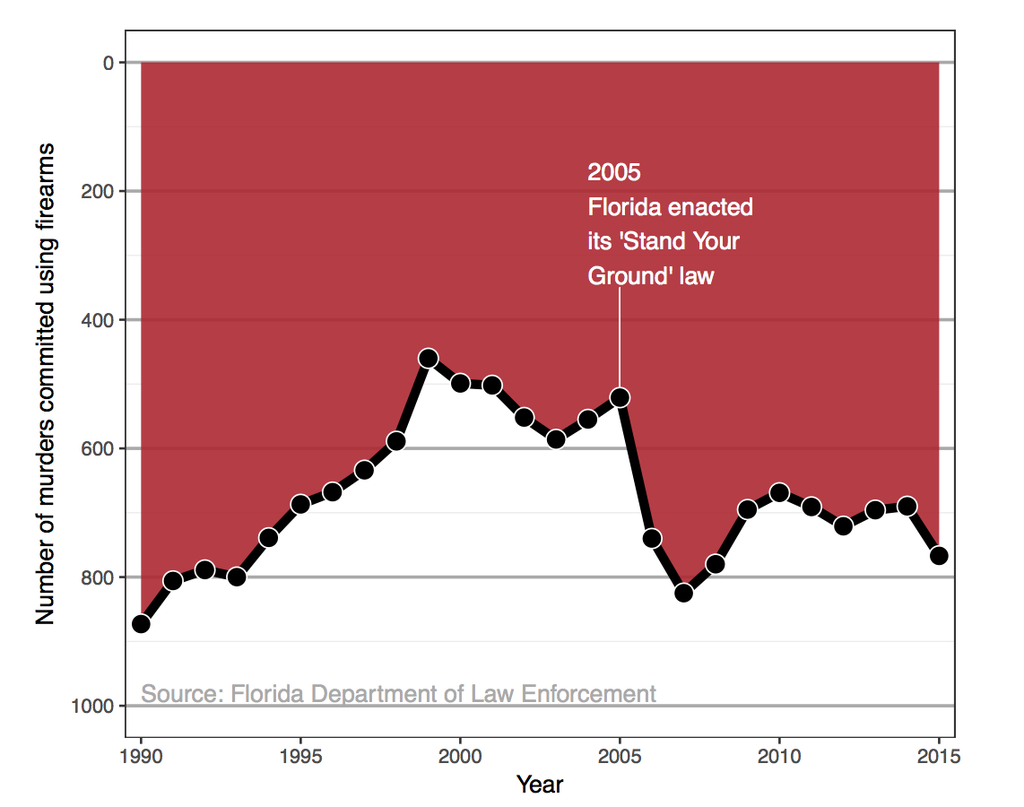

Reproduction of a data graphic reporting the number of gun deaths in Florida over time. The original image was published by Reuters. [@MDSR]

126. What is misleading here?[^127]
     1. Very low data-to-ink ratio?[^128]
     2. Non-intuitive sorting?
     3. Wrong / changing scales?
     4. 1-dim information in 2-D or 3-d?
     5. Inconsistent labeling

[figure not shown]

A tweet by *National Review* on December 14, 2015 showing the change in global temperature over time. [@MDSR]

127. What is misleading here?[^129]
     1. Very low data-to-ink ratio?[^130]
     2. Non-intuitive sorting?
     3. Wrong / changing scales?
     4. 1-dim information in 2-D or 3-d?
     5. Inconsistent labeling

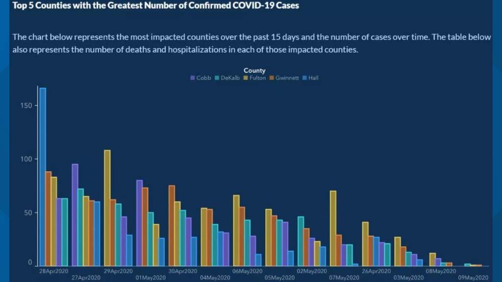

May 10, 2020, Georgia Department of Health, COVID-19 cases for 5 counties across time. https://dph.georgia.gov/covid-19-daily-status-report

128. What is misleading here?[^131]
     1. Very low data-to-ink ratio?[^132]
     2. Non-intuitive sorting?
     3. Wrong / changing scales?
     4. 1-dim information in 2-D or 3-d?
     5. Inconsistent labeling

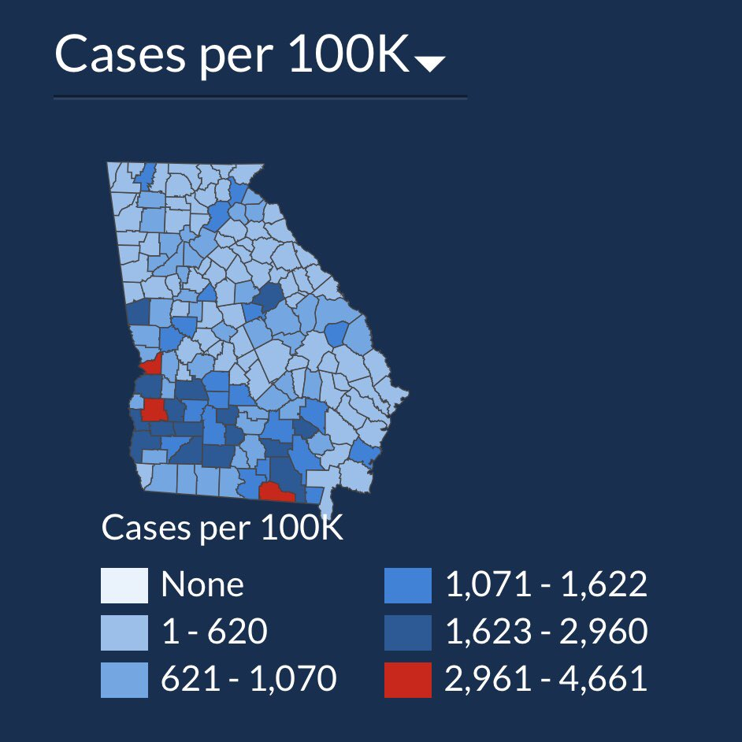

July 2, 2020, Georgia Department of Health, COVID-19 cases per 100K

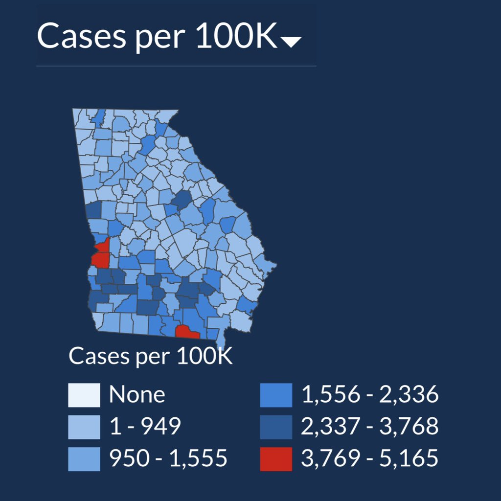

July 17, 2020, https://dph.georgia.gov/covid-19-daily-status-report

129. How often do you read “The Student Life”?[^133]
     1. Every day
     2. 3-5 times a week
     3. Once a week
     4. Rarely
     5. What is “The Student Life”?
130. What do you think is the most common word in the titles of the Student Life opinion articles?[^134]
     1. stop
     2. health
     3. Pomona
     4. CMC
     5. students
131. How can you tell the difference between an element and an attribute (when looking at HTML code)?[^135]
     1. the elements have `.`
     2. the elements have `#`
     3. the elements have `< >`
     4. the elements have `[ ]`
132. How do I find (using `html_elements()`) all the instances of the `<img>` (image) element?[^136]
     1. use selector: `<img>`
     2. use selector: `.img`
     3. use selector: `#img`
     4. use selector: `[img]`
     5. use selector: `img`
133. How do I find (using `html_elements()`) all the instances of the `href=` (URL) attribute?[^137]
     1. use selector: `<href>`
     2. use selector: `.href`
     3. use selector: `#href`
     4. use selector: `[href]`
     5. use selector: `href`
134. What is the difference between an attribute and an element?[^138]
1. an attribute describes an element
2. an element describes an attribute
3. an attribute is the parent of an element
4. an element is the parent of an attribute
135. What is a **SQL** server?[^139]
1. A relational database management system.
2. A software program whose main purpose is to store and retrieve data.
3. A highly secure server that does not allow any database file manipulation during execution.
4. All of the above.
136. When was **SQL** created?[^140]
     1. 1960s
     2. 1970s
     3. 1980s
     4. 1990s
     5. 2000s
137. What type of databases is **SQL** designed for?[^141]
1. hierarchical database management systems.
2. network database management systems.
3. object-oriented database management systems.
4. relational database management systems.
138. Which is bigger:[^142]
     1. computer’s hard drive / storage
     2. computer’s memory / RAM
139. Where are each stored?[^143]
1. **SQL** `tbl` and **R** `tibble` both in storage
2. **SQL** `tbl` and **R** `tibble` both in memory
3. **SQL** `tbl` in storage and **R** `tibble` in memory
4. **SQL** `tbl` in memory and **R** `tibble` in storage
140. Which **SQL** keyword is used to extract data from a database?[^144]
1. OPEN
2. EXTRACT
3. SELECT
4. GET
141. With **SQL**, how to you retrieve a column named “FirstName” from a table named “Persons”?[^145]
1. `SELECT` Persons.FirstName
2. EXTRACT FIRSTNAME `FROM` Persons
3. `SELECT` FirstName `FROM` Persons
4. `SELECT` “FirstName” `FROM` “Persons”
142. With **SQL**, how do you select all the columns from a table named “Persons”?[^146]
1. `SELECT` Persons
2. `SELECT` * `FROM` Persons
3. `SELECT` [all] `FROM` Persons
4. `SELECT` *.Persons
143. With **SQL**, how can you return the number of records in the “Persons” table?[^147]
1. `SELECT` `COLUMNS(*)` `FROM` Persons
2. `SELECT` `COUNT(*)` `FROM` Persons
3. `SELECT` `NO(*)` `FROM` Persons
4. `SELECT` `LEN(*)` `FROM` Persons
144. With **SQL**, how do you select all the records from a table named “Persons” where the value of the column “FirstName” is “Peter”?[^148]
1. `SELECT` * `FROM` Persons `WHERE` FirstName <> ‘Peter’
2. `SELECT` * `FROM` Persons `WHERE` FirstName = ‘Peter’
3. `SELECT` * `FROM` Persons `WHERE` FirstName == ‘Peter’
4. `SELECT` * `FROM` Persons `WHERE` FirstName `LIKE` ‘Peter’
5. `SELECT` [all] `FROM` Persons `WHERE` FirstName = ‘Peter’
145. With **SQL**, how do you select all the records from a table named “Persons” where the “FirstName” is “Peter” and the “LastName” is “Jackson”?[^149]
1. `SELECT` FirstName = ‘Peter’, LastName = ‘Jackson’ `FROM` Persons
2. `SELECT` * `FROM` Persons `WHERE` FirstName = ‘Peter’ & LastName = ‘Jackson’
3. `SELECT` * `FROM` Persons `WHERE` FirstName = ‘Peter’ AND LastName = ‘Jackson’
4. `SELECT` * `FROM` Persons `WHERE` FirstName = ‘Peter’ | LastName = ‘Jackson’
146. Which keyword selects values within a range?[^150]
     1. `BEWTEEN`
     2. `WITHIN`
     3. `RANGE`
147. With **SQL**, how do you select all the records from a table named “Persons” where the “LastName” is alphabetically between (and including) “Hansen” and “Pettersen”?[^151]
     1. `SELECT` LastName > ‘Hansen’ AND LastName < ‘Pettersen’ `FROM` Persons
     2. `SELECT` * `FROM` Persons `WHERE` LastName BETWEEN ‘Hansen’ AND ‘Pettersen’
     3. `SELECT` * `FROM` Persons `WHERE` LastName > ‘Hansen’ AND LastName < ‘Pettersen’
148. Which **SQL** keyword returns only different values?[^152]
     1. `SELECT UNIQUE`
     2. `SELECT DISTINCT`
     3. `SELECT DIFFERENT`
149. Which **SQL** keyword is used to sort the result-set?[^153]
     1. `ORDER BY`
     2. `ORDER`
     3. `SORT`
     4. `SORT BY`
150. What is the difference between the original data and the results set?[^154]
     1. original comes after `SELECT` and results comes after `FROM`
     2. original comes after `FROM` and results comes after `WHERE`
     3. original comes after `WHERE` and results comes after `GROUP BY`
     4. original is the stored data and results comes after `SELECT`
     5. original is the stored data and results comes after `WHERE`
151. With **SQL**, how can you return all the records from a table named “Persons” sorted descending by “FirstName”?[^155]
     1. `SELECT` * `FROM` Persons `ORDER` FirstName `DESC`
     2. `SELECT` * `FROM` Persons `SORT` ‘FirstName’ `DESC`
     3. `SELECT` * `FROM` Persons `ORDER BY` FirstName `DESC`
     4. `SELECT` * `FROM` Persons `SORT BY` ‘FirstName’ `DESC`
152. The OR operator displays a record if ANY conditions listed are true. The AND operator displays a record if ALL of the conditions listed are true.[^156]
     1. TRUE
     2. FALSE
153. In order to `SELECT` the records with foods that are either green or yellow fruit:[^157]
     1. … `WHERE` type = ‘fruit’ AND color = ‘yellow’ OR color = ‘green’
     2. … `WHERE` (type = ‘fruit’ AND color = ‘yellow’) OR color = ‘green’
     3. … `WHERE` type = ‘fruit’ AND (color = ‘yellow’ OR color = ‘green’)
     4. … `WHERE` type = ‘fruit’ AND color = ‘yellow’ AND color = ‘green’
     5. … `WHERE` type = ‘fruit’ AND (color = ‘yellow’ AND color = ‘green’)
154. What is the purpose of a `JOIN`?[^158]
     1. it filters the rows returned by the `SELECT` statement.
     2. it specifies the columns to be retrieved.
     3. it combines rows from two or more tables based on a related column.
     4. it orders the results in ascending or descending order.
155. What is the purpose of the `UNION` operator in SQL?[^159]
     1. it combines the results of two or more `SELECT` statements.
     2. it performs a pattern match on a string.
     3. it retrieves the maximum value in a column.
     4. it filters the rows returned by the `SELECT` statement.
156. What is the purpose of the `INNER JOIN` in SQL?[^160]
     1. it retrieves the maximum value in a column.
     2. it combines rows from two or more tables based on a related column.
     3. it filters the rows returned by the `SELECT` statement.
     4. it performs a pattern match on a string.
157. What is the purpose of the `LEFT JOIN` in SQL?[^161]
     1. it combines rows from two or more tables based on a related column.
     2. it retrieves the maximum value in a column.
     3. it filters the rows returned by the `SELECT` statement.
     4. it performs a pattern match on a string.
158. `RIGHT JOIN` keeps all the rows in …?[^162]
     1. the first table.
     2. the second table.
     3. both tables.
     4. neither table
159. Who is removed in a `RIGHT JOIN`?[^163]
     1. Mick
     2. John
     3. Paul
     4. Keith

[figure not shown]

160. Which variable(s) are removed in a `RIGHT JOIN`?[^164]
     1. name
     2. band
     3. plays
     4. none of them

[figure not shown]

161. In **SQL**, what happens to Mick’s “plays” variables in a `FULL JOIN`?[^165]
     1. Mick is removed
     2. guitar
     3. bass
     4. NA
     5. `NULL`

[figure not shown]

162. What is wrong with this **SQL** clause?[^166]
     1. No comma between selected columns
     2. Can’t have a column and a summary of that column
     3. Use `MEAN()` instead of `AVG()`
     4. Variables aren’t in `flights`
     5. Need a `LIMIT`

```sql
SELECT cancelled, AVG(cancelled)
FROM flights;
```

163. What is wrong with this **SQL** clause?[^167]
     1. Need a `WHERE`
     2. Need a `FROM`
     3. Need a `LIMIT`
     4. Need a `GROUP BY`
     5. Need a `SELECT`

```sql
SELECT flights;
```

164. What is wrong with this **SQL** clause?[^168]
     1. Need a doubl equals: `==`
     2. Need quotes around 2014: `"2014"`
     3. Need quotes around `dep_delay`: `"dep_delay"`
     4. `year = 2014` should go in `WHERE`
     5. Need `GROUP BY year`

```sql
SELECT dep_delay, year = 2014
FROM flights
LIMIT 10;
```

165. What is wrong with this **SQL** clause?[^169]
     1. Can’t `SELECT` a variable from the results set
     2. Can’t `SELECT` a variable from the original data
     3. `SUM()` is not a function in **SQL**
     4. No commas

```sql
SELECT SUM(cancelled) AS num_cancelled,
       num_cancelled / SUM(1) AS pct_cancelled
FROM flights
LIMIT 10;
```

166. With **SQL**, how do you select all the records from a table named “Persons” where the value of the column “FirstName” starts with an “a”?[^170]
     1. `SELECT` * `FROM` Persons `WHERE` FirstName = ’a.*’
     2. `SELECT` * `FROM` Persons `WHERE` FirstName = ’a*’
     3. `SELECT` * `FROM` Persons `WHERE` FirstName `REGEXP` ’a.*’
     4. `SELECT` * `FROM` Persons `WHERE` FirstName `REGEXP` ’a*’
     5. `SELECT` * `FROM` Persons `WHERE` FirstName `REGEXP` ’(?i)a.*’
167. What is the main way to absolutely recognize a record within a database?[^171]
     1. Foreign key
     2. Primary key
     3. Unique key
     4. Natural key
     5. Alternate key
168. What does a foreign key do?[^172]
     1. Directly identifies another table
     2. Directly identifies another column
     3. Gives access to another entire database
     4. Translates the database into another language
169. Which of these would likely be used as a foreign key between a table on student enrollment and student grades?[^173]
     1. grades
     2. tuition
     3. student_name
     4. student_hometown
170. For the student records (for two tables: enrollment and grades), which is the most likely combination?[^174]
     1. name as primary key to both
     2. name as foreign to both
     3. name as primary in enrollment and foreign in grades
     4. name as foreign in enrollment and primary in grades
171. Which of the following is the primary function used to create a Shiny app?[^175]
     1. `shinyApp()`
     2. `createApp()`
     3. `runApp()`
     4. `startShinyApp()`
172. Which of the following Shiny components contains the code for handling user inputs and realizing outputs?[^176]
     1. `ui`
     2. `server`
     3. `runApp()`
     4. `shinyApp()`
173. Which of the following Shiny UI elements is used to allow users to select a single option from a list of choices?[^177]
1. `selectInput()`
2. `radioButtons()`
3. `checkboxGroupInput()`
4. `textInput()`
174. In Shiny, what is the purpose of the `renderText()` function?[^178]
1. To display a plot as text
2. To generate text output based on reactive inputs
3. To create a text input field
4. To render HTML elements
175. What does the `ui` component in a Shiny app represent?[^179]
1. The logic of the application
2. The server-side calculations
3. The user interface elements
4. The global settings for the app
176. Which Shiny function is used to handle reactive expressions in the server function?[^180]
1. `reactive()`
2. `render()`
3. `observe()`
4. `updateInput()`
177. What is the default output type for `renderPlot()` in Shiny?[^181]
     1. plotly chart
     2. ggplot2 plot
     3. base R plot
     4. HTML table
178. Which of the following is the correct way to create a slider input in Shiny?[^182]
     1. `sliderInput("slider", "Slider", min = 1, max = 100, value = 50)`
     2. `inputSlider("slider", min = 1, max = 100)`
     3. `sliderControl("slider", 1, 100)`
     4. `input_slider("slider", 1, 100)`